# Assignment4

Gianina Yumul

9/28/2020

# Assignment Brief

Select between five and 30 locations within a city or metropolitan area. For each location, generate isochrones for the same travel time for at least two different modes. Calculate the area of each isochrone and compare the areas of the isochrones for the two (or more) modes you analyzed. Create three figures (which may or may not be maps) to illustrate the results of your analysis.

For this assignment, I chose to look at Boston Police station point locations. I was curious to see if and where there were overlaps between 10-minute drivesheds and walksheds of police stations, in which neighborhoods those occurred, and if that could lead to any nascent understandings about the extent to which certain neighborhoods are policed (or over-policed).

Credit to Alex Cox for working through a third visualization on Zoom with me.

# Grabbing Data and Setting Up OTP

```r
#Declare libraries while suppressing outputs.
library(osmdata, quietly = TRUE, warn.conflicts = FALSE)
library(opentripplanner, quietly = TRUE, warn.conflicts = FALSE)
library(tidyverse, quietly = TRUE, warn.conflicts = FALSE)
library(sf, quietly = TRUE, warn.conflicts = FALSE)
library(ggthemes, quietly = TRUE, warn.conflicts = FALSE)
library(ggspatial, quietly = TRUE, warn.conflicts = FALSE)
library(wesanderson, quietly = TRUE, warn.conflicts = FALSE)
```

```r
bos_police <- st_read("http://bostonopendata-boston.opendata.arcgis.com/datasets/e5a0066d38ac4e2abbc7918197a4f6af_6.kml?outSR=%7B%22latestWkid%22%3A2249%2C%22wkid%22%3A102686%7D")
MA_state_plane <- "+proj=lcc +lat_1=41.71666666666667 +lat_2=42.68333333333333 +lat_0=41 +lon_0=-71.5 +x_0=200000 +y_0=750000 +ellps=GRS80 +units=m +no_defs"

boston_street_features <- opq(bbox = 'Boston MA USA') %>%
  add_osm_feature(key = 'highway') %>%
  osmdata_sf()

boston_streets <- boston_street_features$osm_lines %>%
  st_transform(crs = MA_state_plane)
```

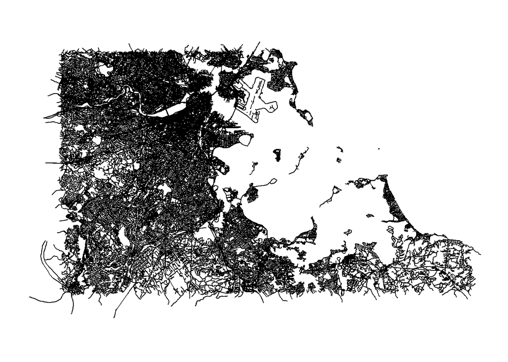

```r
ggplot(boston_streets) +
  geom_sf() +
  theme_map()
```

```r
knitr::opts_chunk$set(echo = TRUE)
path_data <- file.path(getwd(), "OTP")
path_otp <- paste(path_data, "otp.jar",sep = "/")

otp_build_graph(otp = path_otp, dir = path_data, memory = 1024)
```

```
## 2020-10-07 08:26:13 Basic checks completed, building graph, this may take a few minutes
```

```
## The graph will be saved to C:/Users/YumulGianinaValerie/Documents/GitHub/VIS/gyumul-vis/OTP
```

```
## 2020-10-07 08:26:34 Graph built
```

[output not shown]

[output cut: 256 more lines]

```r
otp_setup(otp = path_otp, dir = path_data, memory =1024)
```

```
## 2020-10-07 08:26:35 OTP is loading and may take a while to be useable
```

```
## Router http://localhost:8080/otp/routers/default exists
```

```
## 2020-10-07 08:27:36 OTP is ready to use Go to localhost:8080 in your browser to view the OTP
```

```r
otpcon <- otp_connect()
```

```
## Router http://localhost:8080/otp/routers/default exists
```

# Creating Visualizations

```r
iso_5min_walk <-
  otp_isochrone(otpcon = otpcon, fromPlace = bos_police,
                mode = "WALK", cutoffSec = 600) %>%
  st_transform(crs = MA_state_plane) %>%
  mutate(mode = "walk")

iso_5min_drive <-
  otp_isochrone(otpcon = otpcon, fromPlace = bos_police,
                mode = "CAR", cutoffSec = 600) %>%
  st_transform(crs = MA_state_plane) %>%
  mutate(mode = "drive")

iso_all_modes <- rbind(iso_5min_drive, iso_5min_walk)

otp_stop()
```

```
## [1] "SUCCESS: The process \"java.exe\" with PID 16552 has been terminated."
```

## Isochrones #1

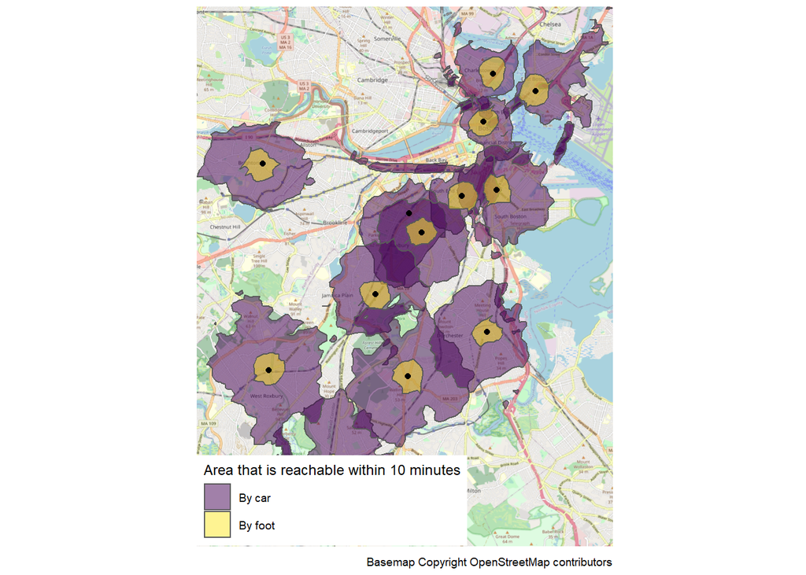

```r
right_side <- st_bbox(iso_all_modes)$xmax
left_side  <- st_bbox(iso_all_modes)$xmin
top_side <- st_bbox(iso_all_modes)$ymax
bottom_side <- st_bbox(iso_all_modes)$ymin

ggplot(iso_all_modes) +
  annotation_map_tile(zoomin = 0, progress = "none") +
  geom_sf(aes(fill = mode), alpha = 0.5) +
  geom_sf(data = bos_police) +
  coord_sf(xlim = c(left_side, right_side),
           ylim = c(bottom_side, top_side), expand = FALSE) +
  scale_fill_viridis_d(name = "Area that is reachable within 10 minutes",
                       labels = c("By car", "By foot")) +
  theme_map() +
  labs(caption = "Basemap Copyright OpenStreetMap contributors")
```

## Isochrones #2

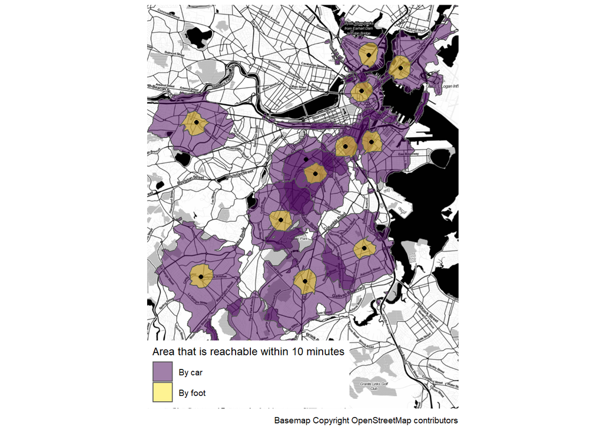

```r
ggplot(iso_all_modes) +
  annotation_map_tile(zoomin = 0, type = "stamenbw", progress = "none") +
  geom_sf(aes(fill = mode), alpha = 0.5) +
  geom_sf(data = bos_police) +
  coord_sf(xlim = c(left_side, right_side),
           ylim = c(bottom_side, top_side), expand = FALSE) +
  scale_fill_viridis_d(name = "Area that is reachable within 10 minutes",
                       labels = c("By car", "By foot")) +
  theme_map() +
  labs(caption = "Basemap Copyright OpenStreetMap contributors")
```

## Scatter Plot

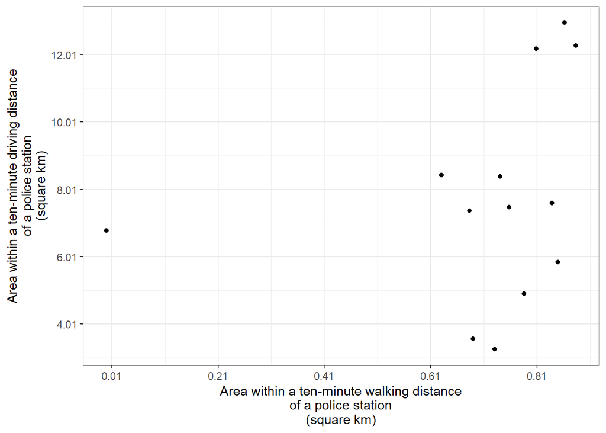

```r
iso_areas <- iso_all_modes %>%
  mutate(area = st_area(iso_all_modes)) %>%
  st_set_geometry(NULL) %>%
  pivot_wider(names_from = mode, values_from = area)

ggplot(iso_areas,
       aes(x = as.numeric(walk), y = as.numeric(drive))) +
  geom_point() +
  scale_x_continuous(name =
            "Area within a ten-minute walking distance\nof a police station\n(square km)",
            breaks = breaks <- seq(10000, 1000000, by = 200000),
            labels = breaks / 1000000) +
  scale_y_continuous(name =
            "Area within a ten-minute driving distance\nof a police station\n(square km)",
            breaks = breaks <- seq(10000, 20000000, by = 2000000),
            labels = breaks / 1000000) +
  theme_bw()
```

## Violin Plot

[figure not shown]

```r
iso_areas <- iso_all_modes %>%
  mutate(area = st_area(iso_all_modes)) %>%
  st_set_geometry(NULL) %>%
  pivot_wider(names_from = mode, values_from = area)

ggplot(iso_areas,
       aes(x = as.numeric(walk), y = as.numeric(drive))) +
  geom_violin() +
  scale_x_continuous(name =
            "Area within a ten-minute walking distance\nof a police station\n(square km)",
            breaks = breaks <- seq(10000, 4000000, by = 200000),
            labels = breaks / 1000000) +
  scale_y_continuous(name =
            "Area within a ten-minute driving distance\nof a police station\n(square km)",
            breaks = breaks <- seq(10000, 20000000, by = 1000000),
            labels = breaks / 10000000) +
  theme_light()
```

## Violin Plot with Points

[figure not shown]

```r
iso_areas <- iso_all_modes %>%
  mutate(area = st_area(iso_all_modes)) %>%
  st_set_geometry(NULL) %>%
  pivot_wider(names_from = mode, values_from = area)

ggplot(iso_areas,
       aes(x = as.numeric(walk), y = as.numeric(drive))) +
  geom_violin() +
  geom_point(position = "jitter",
             size = .8,
             alpha = .8) +
  scale_x_continuous(name =
            "Area within a ten-minute walking distance\nof a police station\n(square km)",
            breaks = breaks <- seq(10000, 4000000, by = 200000),
            labels = breaks / 1000000) +
  scale_y_continuous(name =
            "Area within a ten-minute driving distance\nof a police station\n(square km)",
            breaks = breaks <- seq(0, 20000000, by = 1000000),
            labels = breaks / 10000000) +
  theme_light()
```

# Discussion

Some noticings: - The area of a ten-minute walkshed mostly fell between ~0.6 and ~0.9 square kilometers. - The area of a ten-minute driveshed had greater variability. - The South End, Roxbury, and South Dorchester had larger numbers of overlapping walksheds and drivesheds.